# Homework_3

Dhananjay

2023-02-28

## Q1. Get the Feed Grains dataset

- You will find the dataset here: FeedGrains.csv
- The first two lines are comments, starting with the ‘#’ character
- The file has a header and is comma separated

```r
# Loading the required libraries
library(tidyverse)
# Reading the dataset
feedGrainsData <- read.csv("FeedGrains.csv", header = TRUE, sep = ',', skip = 3)
head(feedGrainsData)
```

```
##   SC_Group_ID  SC_Group_Desc SC_GroupCommod_ID SC_GroupCommod_Desc
## 1           2 Supply and use                17                Oats
## 2           2 Supply and use                17                Oats
## 3           2 Supply and use                17                Oats
## 4           2 Supply and use                17                Oats
## 5           2 Supply and use                17                Oats
## 6           2 Supply and use                17                Oats
##   SC_Geography_ID SortOrder SC_GeographyIndented_Desc SC_Commodity_ID
## 1               1       0.8             United States               3
## 2               1       0.8             United States               3
## 3               1       0.8             United States               3
## 4               1       0.8             United States               3
## 5               1       0.8             United States               3
## 6               1       0.8             United States               3
##   SC_Commodity_Desc SC_Attribute_ID SC_Attribute_Desc SC_Unit_ID
```

[output cut: 20 more lines]

```r
summary(feedGrainsData)
```

```
##   SC_Group_ID    SC_Group_Desc      SC_GroupCommod_ID SC_GroupCommod_Desc
##  Min.   :1.000   Length:454898      Min.   : 8.00     Length:454898
##  1st Qu.:3.000   Class :character   1st Qu.:10.00     Class :character
##  Median :3.000   Mode  :character   Median :12.00     Mode  :character
##  Mean   :2.835                      Mean   :12.55
##  3rd Qu.:3.000                      3rd Qu.:12.00
##  Max.   :7.000                      Max.   :20.00
##                                     NA's   :7773
##  SC_Geography_ID    SortOrder      SC_GeographyIndented_Desc SC_Commodity_ID
##  Min.   :  1.00   Min.   :  0.02   Length:454898             Min.   :  1.00
##  1st Qu.: 30.00   1st Qu.:  1.60   Class :character          1st Qu.:  2.00
##  Median : 51.00   Median : 57.50   Mode  :character          Median : 14.00
##  Mean   : 88.53   Mean   : 76.41                             Mean   : 34.88
##  3rd Qu.:141.00   3rd Qu.:150.00                             3rd Qu.: 76.00
##  Max.   :339.00   Max.   :285.00                             Max.   :212.00
##
##  SC_Commodity_Desc  SC_Attribute_ID SC_Attribute_Desc    SC_Unit_ID
##  Length:454898      Min.   : 1.00   Length:454898      Min.   : 1.000
##  Class :character   1st Qu.:19.00   Class :character   1st Qu.: 7.000
##  Mode  :character   Median :24.00   Mode  :character   Median : 7.000
##                     Mean   :22.77                      Mean   : 7.674
##                     3rd Qu.:24.00                      3rd Qu.: 7.000
##                     Max.   :61.00                      Max.   :46.000
##
##  SC_Unit_Desc          Year_ID     SC_Frequency_ID SC_Frequency_Desc
##  Length:454898      Min.   :1866   Min.   :1.000   Length:454898
##  Class :character   1st Qu.:1995   1st Qu.:1.000   Class :character
##  Mode  :character   Median :2004   Median :1.000   Mode  :character
##                     Mean   :2002   Mean   :1.389
##                     3rd Qu.:2011   3rd Qu.:1.000
##                     Max.   :2019   Max.   :3.000
##
##  Timeperiod_ID    Timeperiod_Desc        Amount
##  Min.   :  1.00   Length:454898      Min.   :      -197
##  1st Qu.:  4.00   Class :character   1st Qu.:         0
##  Median :  8.00   Mode  :character   Median :         2
##  Mean   : 15.93                      Mean   :    656552
##  3rd Qu.: 12.00                      3rd Qu.:        45
##  Max.   :137.00                      Max.   :2597864563
##
```

## Q2. Get the subset of the data corresponding with only annual AND only seed use data (just one dataset, not two)

- Use the field SC_Frequency_Desc to find the records associated with annual observations
- Use the field SC_Attribute_Desc to find the records associated with seed use observations
- Hint: the filter() function from dplyr might be useful

```r
# Loading the required libraries
library(tidyverse)

# Reading the dataset
feedGrainsData <- read.csv("FeedGrains.csv", header = TRUE, sep = ',', skip = 3)

# Creating the subset of data corresponding with only annual AND only seed use observations using filter

annualSeedUseSubsettedData <- filter(feedGrainsData, SC_Frequency_Desc == "Annual" & SC_Attribute_Desc == "Seed use" )

head(annualSeedUseSubsettedData)
```

```
##   SC_Group_ID  SC_Group_Desc SC_GroupCommod_ID SC_GroupCommod_Desc
## 1           2 Supply and use                17                Oats
## 2           2 Supply and use                17                Oats
## 3           2 Supply and use                17                Oats
## 4           2 Supply and use                17                Oats
## 5           2 Supply and use                17                Oats
## 6           2 Supply and use                17                Oats
##   SC_Geography_ID SortOrder SC_GeographyIndented_Desc SC_Commodity_ID
## 1               1       0.8             United States               3
## 2               1       0.8             United States               3
## 3               1       0.8             United States               3
## 4               1       0.8             United States               3
## 5               1       0.8             United States               3
## 6               1       0.8             United States               3
##   SC_Commodity_Desc SC_Attribute_ID SC_Attribute_Desc SC_Unit_ID
```

[output cut: 20 more lines]

## Q3. Use the subsetted annual seed use data to produce a scatterplot of the year by amount seeded, colored by commodity type

- Use the field Year_ID for the year and make sure it is on the x-axis
- Use the field Amount for the amount and it is on the y-axis
- Use the SC_Commodity_Desc for the commodity type
- Make sure all plot labels are clear and visible

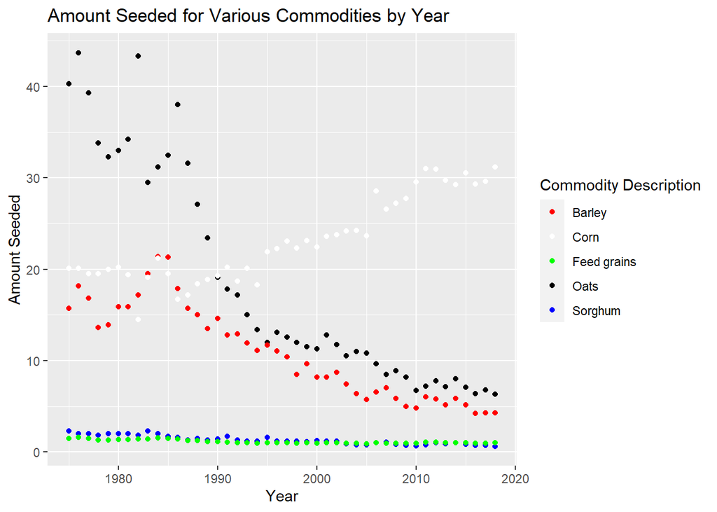

```r
# Loading the required libraries
library(tidyverse)
library(ggplot2)

# Reading the dataset

feedGrainsData <- read.csv("FeedGrains.csv", header = TRUE, sep = ',', skip = 3)

# Creating the subset of data corresponding with only annual AND only seed use observations using filter

annualSeedUseSubsettedData <- filter(feedGrainsData, SC_Frequency_Desc == "Annual" & SC_Attribute_Desc == "Seed use" )

# Plotting the subsetted annual seed use data using the scatterplot of year by amount seeded, colored by commodity type

ggplot(annualSeedUseSubsettedData, aes(x = Year_ID, y = Amount, group = SC_Commodity_Desc)) +
  geom_point(aes(color = SC_Commodity_Desc)) +
  scale_color_manual(values = c("Red", "White", "Green", "Black", "Blue")) +
  labs(title = "Amount Seeded for Various Commodities by Year",
       x = "Year",
       y = "Amount Seeded",
       color = "Commodity Description")
```

## Q4. Examine the built-in R dataset, Orange

- Look at the collection of built-in datasets (hint: ?data)
- Consider the Orange data set in particular (hint: ?Orange)
- Describe the mode() and class() of all variables in the data set (hint: ?Orange)

```r
# Looking into the collection of built-in R datasets
?data
```

```
## starting httpd help server ... done
```

```r
# List out all the available built-in R datasets
# data()

# Looking into the Orange dataset
?Orange
#data(Orange)
print(Orange)
```

```
##    Tree  age circumference
## 1     1  118            30
## 2     1  484            58
## 3     1  664            87
## 4     1 1004           115
## 5     1 1231           120
## 6     1 1372           142
## 7     1 1582           145
## 8     2  118            33
## 9     2  484            69
## 10    2  664           111
## 11    2 1004           156
## 12    2 1231           172
## 13    2 1372           203
## 14    2 1582           203
```

[output cut: 21 more lines]

```r
# Describing the mode of all variables in the dataset
mode(Orange$Tree)
```

```
## [1] "numeric"
```

```r
mode(Orange$age)
```

```
## [1] "numeric"
```

```r
mode(Orange$circumference)
```

```
## [1] "numeric"
```

```r
# Describing the class of all variables in the dataset
class(Orange$Tree)
```

```
## [1] "ordered" "factor"
```

```r
class(Orange$age)
```

```
## [1] "numeric"
```

```r
class(Orange$circumference)
```

```
## [1] "numeric"
```

## Q5. Plot and analyze the Orange data set

- Produce one grouped bar plot, where the age and the specific tree number is on the x-axis, while the circumference is on the y-axis – group by age

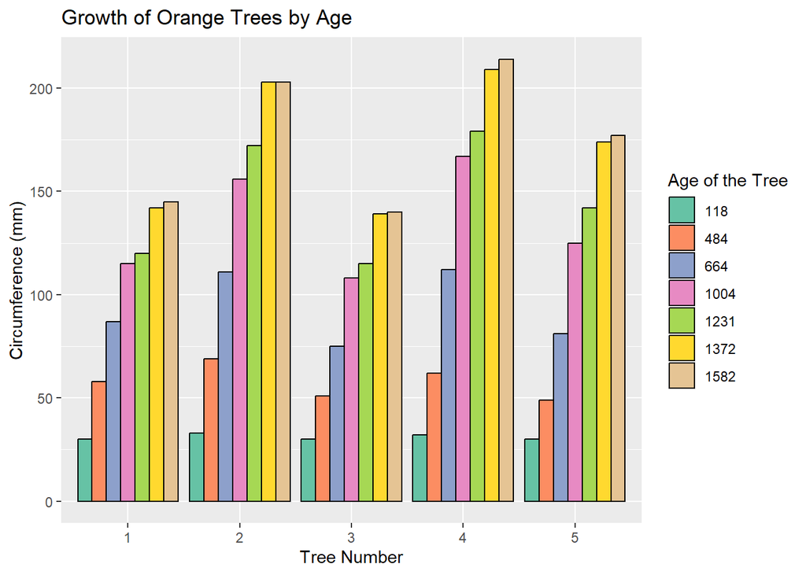

```r
# Loading the required libraries
library(tidyverse)
library(ggplot2)
library(RColorBrewer)

# Converting the Tree and age variable to factor
Orange$Tree <- factor(Orange$Tree, levels = unique(Orange$Tree))
Orange$age <- factor(Orange$age)

# Creating a grouped bar plot with age and tree no. on X-axis and circumference on Y-axis
# Grouped by age

ggplot(Orange, aes(x = Tree, y = circumference, fill = age)) +
  geom_bar(stat = "identity", position = "dodge", color="black") +
  scale_fill_brewer(palette = "Set2") +
  labs(title = "Growth of Orange Trees by Age",
       x = "Tree Number",
       y = "Circumference (mm)",
       fill = "Age of the Tree")
```

- Produce one grouped bar plot, where the age and the specific tree number is on the x-axis, while the circumference is on the y-axis – group by tree ID number

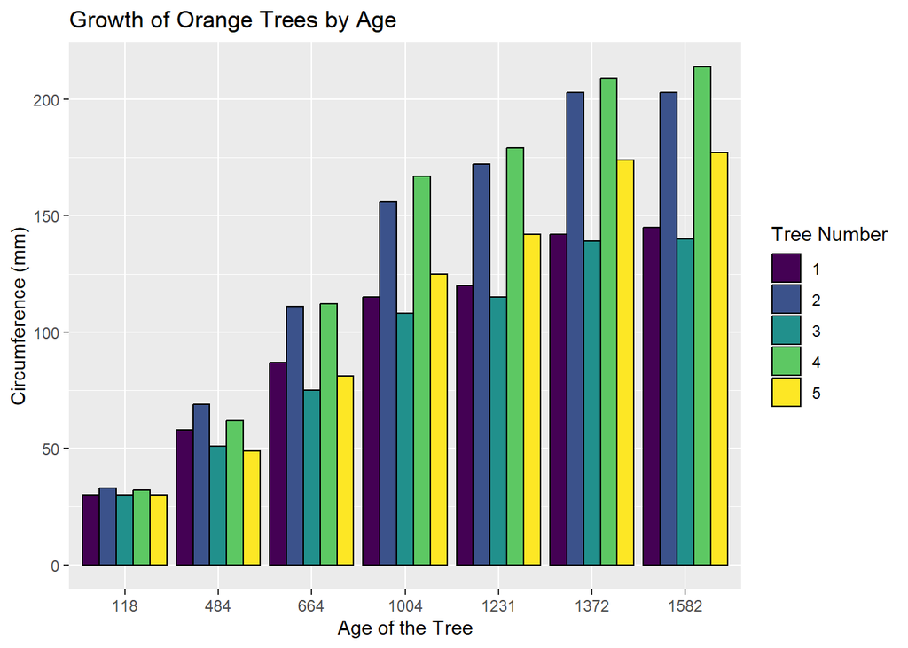

```r
# Loading the required libraries
library(tidyverse)
library(ggplot2)

# Converting the Tree and age variable to factor
Orange$Tree <- factor(Orange$Tree, levels = unique(Orange$Tree))
Orange$age <- factor(Orange$age)

# Creating a grouped bar plot with age and tree no. on X-axis and circumference on Y-axis
# Grouped by tree ID number

ggplot(Orange, aes(x = age, y = circumference, fill = Tree)) +
  geom_bar(stat = "identity", position = "dodge", color="black") +
  labs(title = "Growth of Orange Trees by Age",
       x = "Age of the Tree",
       y = "Circumference (mm)",
       fill = "Tree Number")
```

- Make sure all plot labels are clear and visible, in both plots
- If you have trouble because something is being treated as a number that you want treated as a factor, recall that you can use the factor() function to convert
- Suppose you are interested in comparing across ages for a specific tree primarily, and only secondarily across different trees. Which plot would you prefer?

Answer: The first bar plot is more preferable over the second one, if we are interested in comparing across ages for a specific tree. In the first bar plot, the generated bars are grouped by age which provides users a convenient way to compare the circumference of a specific tree at various ages.